# Objects and Classes, Constructors

### Classes

Classes have been used from the beginning of this course. Most important thing to understand about a class is that it defines a new data type. A class is a template or a blueprint from which objects are made. The great example of a class is a cookie cutter. Cookies are objects themselves. When you counstruct an object from a class you created an **instance** of a class. When you define a class, you declare its exact form and nature. You do this by specifying the data that it contains and the code that operates on that data. While very simple classes may contain only code or only data, most real-world classes contain both. As you will see, a class’ code defines the interface to its data.

As you may have noticed we always use classes to create even the simplest java application. A class is declared by use of the `class` keyword.

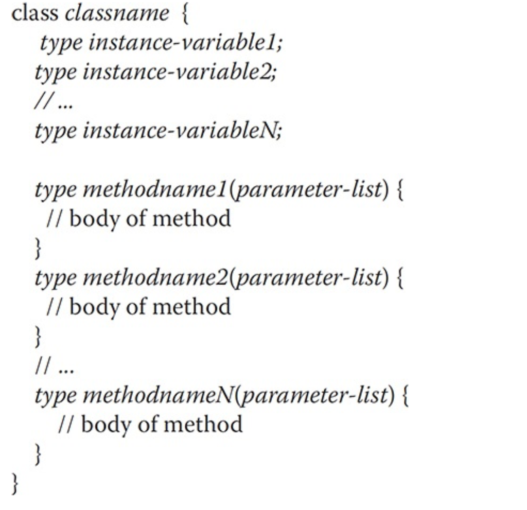

The data, or variables, defined within a class are called **instance variables**. The code is contained within **methods**. Collectively, the methods and variables defined within a class are called **members** of the class. In most classes, the instance variables are acted upon and accessed by the methods defined for that class. Thus, as a general rule, it is the methods that determine how a class’ data can be used. Variables defined within a class are called instance variables because each instance of the class (that is, each object of the class) contains its own copy of these variables.

All methods have the same general form as main( ), which we have been using thus far. However, most methods will not be specified as static or public. Notice that the general form of a class does not specify a main( ) method. Java classes do not need to have a main( )method. You only specify one if that class is the starting point for your program. Further, some kinds of Java applications don’t require a main( ) method at all.